```python
%matplotlib inline
import numpy as np
import matplotlib.pyplot as plt
import random

from sklearn.linear_model import LogisticRegression
```

# Sigmoid ,ratio odds,log odd.The origin of sigmoid

```python
z_f = lambda x,y : 2*x+4*y + b
```

```python
x = np.linspace(-5,5,100) #generate array in interval between [-5,5]
arr = np.dstack(np.meshgrid(x, x)).reshape(-1, 2) #generate cartesian product
```

##### Every number $[-\infty:\infty]$ handled from sigmoid function produces the number between $[0,1]$ which makes the sigmoid function very convenient tool for problem related with prediction or classification.

```python
arr.dot(coef.T) ### generate the arg for logistic regression dot product between data and  coefincien wich is a just a linear combination
```

```
array([-20.       , -19.8989899, -19.7979798, ...,  19.7979798,
        19.8989899,  20.       ])
```

```python
def sigmoid(z):
    return 1/(1+np.exp(-z))
```

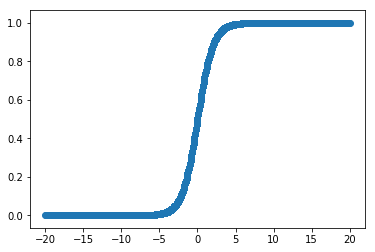

```python
z = arr.dot(coef.T)
y= sigmoid(z)

plt.scatter(z,y)
```

### What is the origin of sigmoid function, From where come from this special function?

### Odds Ratio

##### Odds ratio is is the probability to occur some event dividen to probability to not occur .Matematicaly written $$odds = \frac{P(A)}{1-P(A)} $$ because the probability to something not hapening is $1-P(A)$ how loog like this function ,as we know that the $P(A)\in [0,1]$ the function look like this

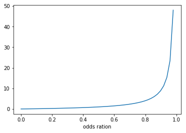

```python
p = np.linspace(0,1)
odds = p/(1-p)
plt.plot(p,odds)
plt.xlabel("probability")
plt.xlabel("odds ration")
```

##### we can see that the function is not symetric the probability to something occur is between $[1,\infty]$ and to not occur $[0,1]$

##### we can transform it in other form of function which is basically doesn't lose the the its meaning ,but it look like much convenient for our future desired results and searching

##### This new function is called log odds function wich is matematicaly look like this :

$$ log(\frac{P(A)}{1-P(A)}) $$

##### This is just process of applying the natural logarithm to log-ratio

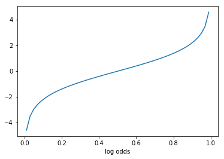

```python
p = np.linspace(0.01,0.99)
odds = p/(1-p)
plt.plot(p,np.log(odds))
plt.xlabel("probability")
plt.xlabel("log odds")
```

### The main important fact of above graphics is that the log-odds varies between $[-\infty:\infty]$. This fact make it the convininet to be use for a fiting with given data withod limnit. The main point of logistic regression begin with the assumption of that :

# $$log(\frac{p}{1-p}) = \beta_i x_i +a \; \; \; \; \; \; \; \; \; \; \; \; \; \; (1) $$

The both sides of equation (1) If we raise up on exponent.

$$e^{log(\frac{p}{1-p})} = e^{\beta_i x_i +a} \;<=> \frac{p}{1-p} = e^{\beta_i x_i +a} \; <=> p = e^{\beta_i x_i +a}(1-p) \; <=> $$

$$p = e^{\beta_i x_i +a} + -p.e^{\beta_i x_i +a} \; <=> $$
$$p(1 +e^{\beta_i x_i +a} ) = e^{\beta_i x_i +a} \; <=> $$
$$p= \frac{e^{\beta_i x_i +a}}{(1 +e^{\beta_i x_i +a} ) } \; = $$
$$p= \frac{ (e^{\beta_i x_i +a})e^{-(\beta_i x_i +a}) }{(1 +e^{\beta_i x_i +a} )e^{-(\beta_i x_i +a}) } \; <=> $$
$$p= \frac{1}{1 +e^{-(\beta_i x_i +a)} } \; <=> $$
$$p= \frac{1}{1 +e^{-z} } \; \; \; where\; z=\beta_i x_i +a => $$
$$p= \frac{1}{1 +e^{-z}} \; \; \; \; \; \; (2) $$

The logistic regression is how to find the best $z=x_i\theta_i +\theta_0$ .